# Preprocessing of the Fantom5 data

Urwah Nawaz

2023-08-07

## 1. Introduction

In this markdown, I will be preprocessing the Fantom5 metadata annotations. These annotations were acquired from multiple different sources including Noguchi et al (2017), and from different labs. As a result, the metadata annotations are not consistent or may contain missing informtion.

In this workbook, I will systematically go through the metadata files I have retrieved from each source so a consensus can be agreed upon on which information we can keep and which we can discard for the purpose of BITHub.

```r
source("functions.R")
library(recount3)
library(magrittr)
library(tibble)
library(reshape2)
library(SummarizedExperiment)
library(corrplot)
library(dplyr)
library(DT)
library(ggvenn)
library(readxl)
```

## 2. Metadata files

Two metadata files were retrived for the Fantom5 CAGE dataset.

1. From Hamid: 889 samples - already preprocessed, mainly for Brain
2. Noguchi et al (2017) - 827 smaples in a human readible format.

```r
f5_hamid = read.delim("/home/neuro/Documents/BrainData/Bulk/Fantom5/FANTOM5/Fantom5SamplesAnnotated.csv", sep = ",")

f5_hamid %<>%
  mutate(SampleID = gsub("\\..*", "", Library))


f5_hamid %>%
   DT::datatable(caption=
      " Metadata annotations acquired from Hamid. These annotations do not contain Sex or Age.
      ")
```

|  | Sample | Library | Sample.category | Tissue.category | useForWGCNA | SampleID | Region | DevStage |
| --- | --- | --- | --- | --- | --- | --- | --- | --- |
| 1 | medial temporal gyrus - adult, donor10196 | CNhs13809.10183.103D3 | tissues | adult brain tissue | yes | CNhs13809 | CTX | adult |
| 2 | medial temporal gyrus, adult, donor10252 | CNhs12310.10150.102I6 | tissues | adult brain tissue | yes | CNhs12310 | CTX | adult |
| 3 | medial temporal gyrus, donor10252 | CNhs12316.10156.103A3 | tissues | adult brain tissue | yes | CNhs12316 | CTX | adult |
| 4 | occipital cortex - adult, donor10196 | CNhs13798.10172.103C1 | tissues | adult brain tissue | yes | CNhs13798 | CTX | adult |
| 5 | occipital cortex, adult, donor10252 | CNhs12320.10163.103B1 | tissues | adult brain tissue | yes | CNhs12320 | CTX | adult |
| 6 | parietal lobe - adult, donor10196 | CNhs13797.10171.103B9 | tissues | adult brain tissue | yes | CNhs13797 | CTX | adult |
| 7 | parietal lobe, adult, donor10252 | CNhs12317.10157.103A4 | tissues | adult brain tissue | yes | CNhs12317 | CTX | adult |
| 8 | parietal lobe, adult, pool1 | CNhs10641.10034.101E7 | tissues | adult brain tissue | yes | CNhs10641 | CTX | adult |
| 9 | paracentral gyrus, adult, pool1 | CNhs10642.10035.101E8 | tissues | adult brain tissue | yes | CNhs10642 | CTX | adult |
| 10 | postcentral gyrus, adult, pool1 | CNhs10638.10032.101E5 | tissues | adult brain tissue | yes | CNhs10638 | CTX | adult |

[output cut: 879 more lines]

```r
HS = read_excel("/home/neuro/Documents/BrainData/Bulk/Fantom5/FANTOM5/HumanSamples2.0.sdrf.xlsx") %>% as.data.frame()
colnames(HS)[2] = c("FFID")

other_supp = read.table("/home/neuro/Documents/BrainData/Bulk/Fantom5/FANTOM5/DRA002747.txt", fill = TRUE, header=TRUE)
merged = merge(HS , other_supp, by= "FFID")


merged %>%
     DT::datatable(caption=
      " Metadata annotations from  Noguchi et al (2017). These annotations are more detailed and contain Sources, Age, Sex, Preparation Protocol. However additional preprocessing needs to be done to ensure column name consistency.
      ")
```

|  | FFID | Source Name | Charateristics [description] | Characteristics [catalog_id] | Characteristics [Category] | Chracteristics [Species] | Characteristics [Sex] | Characteristics [Age] | Characteristics [Developmental stage] | Characteristics[Tissue] | Characteristics [Cell lot] | Characteristics [Cell type] | Characteristics [Catalogue ID] | Characteristics [Collaboration] | Characteristics [Provider] | Protocol REF | Extract Name | Material Type | LibraryID | DRA_sample_accession | DRA_experiment_accession | DRA_run_accession | DRA_bam_accession | DRA_ctss_accession | Experimenet_method |
| --- | --- | --- | --- | --- | --- | --- | --- | --- | --- | --- | --- | --- | --- | --- | --- | --- | --- | --- | --- | --- | --- | --- | --- | --- | --- |
| 1 | FF:10152-102I8 | 10152-102I8 | putamen, adult, donor10252 |  | tissues | Human (Homo sapiens) | female | 76 |  | putamen | NA | CELL MIXTURE - tissue sample | NA | Peter Heutink |  | OP-RNA-extraction-totalRNA-miRNeasy_Mini-v1.0 | 10152-102I8 | Total RNA | CNhs13912 | SAMD00021147 | DRX023588 | DRR025983 | DRZ004408 | DRZ005235 | CAGE |
| 2 | FF:10184-103D4 | 10184-103D4 | adipose, donor1 | 2010-78-IT | tissues | Human (Homo sapiens) | female | 43 |  | adipose tissue | NA | CELL MIXTURE - tissue sample | NA | Peter Arner (Karolinska Institutet) |  | OP-RNA-extraction-totalRNA-miRNeasy_Mini-v1.0 | 10184-103D4 | Total RNA | CNhs13972 | SAMD00021148 | DRX023576 | DRR025971 | DRZ004396 | DRZ005223 | CAGE |
| 3 | FF:10185-103D5 | 10185-103D5 | adipose, donor2 | 2010-79-IT | tissues | Human (Homo sapiens) | female | 42 |  | adipose tissue | NA | CELL MIXTURE - tissue sample | NA | Peter Arner (Karolinska Institutet) |  | OP-RNA-extraction-totalRNA-miRNeasy_Mini-v1.0 | 10185-103D5 | Total RNA | CNhs13973 | SAMD00021149 | DRX023577 | DRR025972 | DRZ004397 | DRZ005224 | CAGE |
| 4 | FF:10186-103D6 | 10186-103D6 | adipose, donor3 | 2010-84-IT | tissues | Human (Homo sapiens) | female | 64 |  | adipose tissue | NA | CELL MIXTURE - tissue sample | NA | Peter Arner (Karolinska Institutet) |  | OP-RNA-extraction-totalRNA-miRNeasy_Mini-v1.0 | 10186-103D6 | Total RNA | CNhs13974 | SAMD00021150 | DRX023578 | DRR025973 | DRZ004398 | DRZ005225 | CAGE |
| 5 | FF:10187-103D7 | 10187-103D7 | adipose, donor4 | 2010-89-IT | tissues | Human (Homo sapiens) | female | 28 |  | adipose tissue | NA | CELL MIXTURE - tissue sample | NA | Peter Arner (Karolinska Institutet) |  | OP-RNA-extraction-totalRNA-miRNeasy_Mini-v1.0 | 10187-103D7 | Total RNA | CNhs13975 | SAMD00021151 | DRX023579 | DRR025974 | DRZ004399 | DRZ005226 | CAGE |
| 6 | FF:10352-105E1 | 10352-105E1 | medial frontal gyrus, newborn, donor10223 |  | tissues | Human (Homo sapiens) | male | 0 |  | medial frontal gyrus |  | CELL MIXTURE - tissue sample |  | Peter Heutink |  | OP-RNA-extraction-totalRNA-miRNeasy_Mini-v1.0 | 10352-105E1 | Total RNA | CNhs14069 | SAMD00021161 | DRX023553 | DRR025948 | DRZ004373 | DRZ005200 | CAGE |
| 7 | FF:10353-105E2 | 10353-105E2 | medial temporal gyrus, newborn, donor10223 |  | tissues | Human (Homo sapiens) | male | 0 |  | medial temporal gyrus |  | CELL MIXTURE - tissue sample |  | Peter Heutink |  | OP-RNA-extraction-totalRNA-miRNeasy_Mini-v1.0 | 10353-105E2 | Total RNA | CNhs14070 | SAMD00021162 | DRX023554 | DRR025949 | DRZ004374 | DRZ005201 | CAGE |
| 8 | FF:10354-105E3 | 10354-105E3 | caudate nucleus, newborn, donor10223 |  | tissues | Human (Homo sapiens) | male | 0 |  | caudate nucleus |  | CELL MIXTURE - tissue sample |  | Peter Heutink |  | OP-RNA-extraction-totalRNA-miRNeasy_Mini-v1.0 | 10354-105E3 | Total RNA | CNhs14071 | SAMD00021163 | DRX023555 | DRR025950 | DRZ004375 | DRZ005202 | CAGE |
| 9 | FF:10355-105E4 | 10355-105E4 | occipital cortex, newborn, donor10223 |  | tissues | Human (Homo sapiens) | male | 0 |  | occipital cortex |  | CELL MIXTURE - tissue sample |  | Peter Heutink |  | OP-RNA-extraction-totalRNA-miRNeasy_Mini-v1.0 | 10355-105E4 | Total RNA | CNhs14073 | SAMD00021164 | DRX023556 | DRR025951 | DRZ004376 | DRZ005203 | CAGE |
| 10 | FF:10356-105E5 | 10356-105E5 | parietal lobe, newborn, donor10223 |  | tissues | Human (Homo sapiens) | male | 0 |  | parietal cortex |  | CELL MIXTURE - tissue sample |  | Peter Heutink |  | OP-RNA-extraction-totalRNA-miRNeasy_Mini-v1.0 | 10356-105E5 | Total RNA | CNhs14074 | SAMD00021165 | DRX023557 | DRR025952 | DRZ004377 | DRZ005204 | CAGE |

[output cut: 817 more lines]

### 2.1 Preprocessing

```r
colnames(merged) = c("FFID",
                     "SourceName",
                     "Characteristic",
                     "Catalog_ID",
                     "SampleType",
                     "Species",
                     "Sex",
                     "AgeNumeric",
                     "Stage",
                     "Tissue",
                     "CellLot",
                     "CellType",
                     "Catalogue ID",
                     "Collaboration",
                     "Provider",
                     "Protocol",
                     "ExtrctName",
                     "MaterialType",
                     "LibraryID",
                     "DRA_sample_accession",
                     "DRA_experiment_accession",
                     "DRA_run_accession",
                     "DRA_bam_accession",
                     "DRA_ctss_accession",
                     "Experimenet_method")

merged_formatted = merged %>%
  dplyr::select(-c("Provider", "Catalogue ID", "Stage",
                   "CellLot", "Catalog_ID")) %>%
  mutate(Sex = gsub("female", "F", Sex),
         Sex = gsub("male", "M", Sex),
         Sex = gsub("n/a", "NA", Sex),
         Sex = gsub("UNDEFINED_SEX_TYPE", "Undefined or Unknown", Sex),
         Sex =gsub("unknown", "Undefined or Unknown", Sex),
         Tissue = str_to_sentence(Tissue),
         CellType =str_to_sentence(CellType),
         DonorID = ifelse(grepl("donor",  Characteristic), Characteristic, NA)) %>%
  mutate(DonorID = gsub(".*, ", "", DonorID)) %>%
  mutate(DonorID = str_to_sentence(DonorID),
         CellLine = ifelse(grepl("cell line", Characteristic), Characteristic, NA)) %>%
  dplyr::rename("SampleID" = "LibraryID")
```

```r
merged_formatted %>%
  DT::datatable(caption = "Formatted columns from Noguchi et al (2017). This includes splitting the characteristics column into a seperate column for donor IDs. Further subsetting may be needed.")
```

|  | FFID | SourceName | Characteristic | SampleType | Species | Sex | AgeNumeric | Tissue | CellType | Collaboration | Protocol | ExtrctName | MaterialType | SampleID | DRA_sample_accession | DRA_experiment_accession | DRA_run_accession | DRA_bam_accession | DRA_ctss_accession | Experimenet_method | DonorID | CellLine |
| --- | --- | --- | --- | --- | --- | --- | --- | --- | --- | --- | --- | --- | --- | --- | --- | --- | --- | --- | --- | --- | --- | --- |
| 1 | FF:10152-102I8 | 10152-102I8 | putamen, adult, donor10252 | tissues | Human (Homo sapiens) | F | 76 | Putamen | Cell mixture - tissue sample | Peter Heutink | OP-RNA-extraction-totalRNA-miRNeasy_Mini-v1.0 | 10152-102I8 | Total RNA | CNhs13912 | SAMD00021147 | DRX023588 | DRR025983 | DRZ004408 | DRZ005235 | CAGE | Donor10252 |  |
| 2 | FF:10184-103D4 | 10184-103D4 | adipose, donor1 | tissues | Human (Homo sapiens) | F | 43 | Adipose tissue | Cell mixture - tissue sample | Peter Arner (Karolinska Institutet) | OP-RNA-extraction-totalRNA-miRNeasy_Mini-v1.0 | 10184-103D4 | Total RNA | CNhs13972 | SAMD00021148 | DRX023576 | DRR025971 | DRZ004396 | DRZ005223 | CAGE | Donor1 |  |
| 3 | FF:10185-103D5 | 10185-103D5 | adipose, donor2 | tissues | Human (Homo sapiens) | F | 42 | Adipose tissue | Cell mixture - tissue sample | Peter Arner (Karolinska Institutet) | OP-RNA-extraction-totalRNA-miRNeasy_Mini-v1.0 | 10185-103D5 | Total RNA | CNhs13973 | SAMD00021149 | DRX023577 | DRR025972 | DRZ004397 | DRZ005224 | CAGE | Donor2 |  |
| 4 | FF:10186-103D6 | 10186-103D6 | adipose, donor3 | tissues | Human (Homo sapiens) | F | 64 | Adipose tissue | Cell mixture - tissue sample | Peter Arner (Karolinska Institutet) | OP-RNA-extraction-totalRNA-miRNeasy_Mini-v1.0 | 10186-103D6 | Total RNA | CNhs13974 | SAMD00021150 | DRX023578 | DRR025973 | DRZ004398 | DRZ005225 | CAGE | Donor3 |  |
| 5 | FF:10187-103D7 | 10187-103D7 | adipose, donor4 | tissues | Human (Homo sapiens) | F | 28 | Adipose tissue | Cell mixture - tissue sample | Peter Arner (Karolinska Institutet) | OP-RNA-extraction-totalRNA-miRNeasy_Mini-v1.0 | 10187-103D7 | Total RNA | CNhs13975 | SAMD00021151 | DRX023579 | DRR025974 | DRZ004399 | DRZ005226 | CAGE | Donor4 |  |
| 6 | FF:10352-105E1 | 10352-105E1 | medial frontal gyrus, newborn, donor10223 | tissues | Human (Homo sapiens) | M | 0 | Medial frontal gyrus | Cell mixture - tissue sample | Peter Heutink | OP-RNA-extraction-totalRNA-miRNeasy_Mini-v1.0 | 10352-105E1 | Total RNA | CNhs14069 | SAMD00021161 | DRX023553 | DRR025948 | DRZ004373 | DRZ005200 | CAGE | Donor10223 |  |
| 7 | FF:10353-105E2 | 10353-105E2 | medial temporal gyrus, newborn, donor10223 | tissues | Human (Homo sapiens) | M | 0 | Medial temporal gyrus | Cell mixture - tissue sample | Peter Heutink | OP-RNA-extraction-totalRNA-miRNeasy_Mini-v1.0 | 10353-105E2 | Total RNA | CNhs14070 | SAMD00021162 | DRX023554 | DRR025949 | DRZ004374 | DRZ005201 | CAGE | Donor10223 |  |
| 8 | FF:10354-105E3 | 10354-105E3 | caudate nucleus, newborn, donor10223 | tissues | Human (Homo sapiens) | M | 0 | Caudate nucleus | Cell mixture - tissue sample | Peter Heutink | OP-RNA-extraction-totalRNA-miRNeasy_Mini-v1.0 | 10354-105E3 | Total RNA | CNhs14071 | SAMD00021163 | DRX023555 | DRR025950 | DRZ004375 | DRZ005202 | CAGE | Donor10223 |  |
| 9 | FF:10355-105E4 | 10355-105E4 | occipital cortex, newborn, donor10223 | tissues | Human (Homo sapiens) | M | 0 | Occipital cortex | Cell mixture - tissue sample | Peter Heutink | OP-RNA-extraction-totalRNA-miRNeasy_Mini-v1.0 | 10355-105E4 | Total RNA | CNhs14073 | SAMD00021164 | DRX023556 | DRR025951 | DRZ004376 | DRZ005203 | CAGE | Donor10223 |  |
| 10 | FF:10356-105E5 | 10356-105E5 | parietal lobe, newborn, donor10223 | tissues | Human (Homo sapiens) | M | 0 | Parietal cortex | Cell mixture - tissue sample | Peter Heutink | OP-RNA-extraction-totalRNA-miRNeasy_Mini-v1.0 | 10356-105E5 | Total RNA | CNhs14074 | SAMD00021165 | DRX023557 | DRR025952 | DRZ004377 | DRZ005204 | CAGE | Donor10223 |  |

[output cut: 817 more lines]

## 3. Overlap with the Expression matrix

The expression matrix for Fantom5 was downloaded from the Consortium website. It contains 1829 samples., and 75,105 transcript annotations

```r
f5_osc =  read.delim("/home/neuro/Documents/BrainData/Bulk/Fantom5/FANTOM5/FANTOM5PHASE1and2gencodev19transcriptexpression(robustpromoter-50bp5primeend).osc")

head(f5_osc)[1:10] %>%
   DT::datatable(caption=
      "The first 10 columns of the Fantom5 expression matrix.
      ")
```

|  | eedb.chrom | eedb.start.0base | eedb.end | eedb.name | eedb.score | eedb.strand | gff.attributes | exp.rle.CNhs14406_ctss | exp.rle.CNhs14407_ctss | exp.rle.CNhs14408_ctss |
| --- | --- | --- | --- | --- | --- | --- | --- | --- | --- | --- |
| 1 | chrM | 576 | 647 | ENST00000387314.1 | 690366 | + | gff:source=ENSEMBL;gff:frame=.;gff:attributes=gene_id 'ENSG00000210049.1'; transcript_id 'ENST00000387314.1'; gene_type 'Mt_tRNA'; gene_status 'KNOWN'; gene_name 'MT-TF'; transcript_type 'Mt_tRNA'; tr… | 187.44 | 177.42 | 218.47 |
| 2 | chrM | 647 | 1601 | ENST00000389680.2 | 405652 | + | gff:source=ENSEMBL;gff:frame=.;gff:attributes=gene_id 'ENSG00000211459.2'; transcript_id 'ENST00000389680.2'; gene_type 'Mt_rRNA'; gene_status 'KNOWN'; gene_name 'MT-RNR1'; transcript_type 'Mt_rRNA'; … | 97.33 | 122.27 | 144.23 |
| 3 | chrM | 1601 | 1670 | ENST00000387342.1 | 18263.5 | + | gff:source=ENSEMBL;gff:frame=.;gff:attributes=gene_id 'ENSG00000210077.1'; transcript_id 'ENST00000387342.1'; gene_type 'Mt_tRNA'; gene_status 'KNOWN'; gene_name 'MT-TV'; transcript_type 'Mt_tRNA'; tr… | 13.38 | 23.58 | 24.74 |
| 4 | chrM | 1670 | 3229 | ENST00000387347.2 | 10344800 | + | gff:source=ENSEMBL;gff:frame=.;gff:attributes=gene_id 'ENSG00000210082.2'; transcript_id 'ENST00000387347.2'; gene_type 'Mt_rRNA'; gene_status 'KNOWN'; gene_name 'MT-RNR2'; transcript_type 'Mt_rRNA'; … | 2485.61 | 6275.47 | 8024.43 |
| 5 | chrM | 3229 | 3304 | ENST00000386347.1 | 286628 | + | gff:source=ENSEMBL;gff:frame=.;gff:attributes=gene_id 'ENSG00000209082.1'; transcript_id 'ENST00000386347.1'; gene_type 'Mt_tRNA'; gene_status 'KNOWN'; gene_name 'MT-TL1'; transcript_type 'Mt_tRNA'; t… | 63.89 | 71.11 | 92.54 |
| 6 | chrM | 3306 | 4262 | ENST00000361390.2 | 2217800 | + | gff:source=ENSEMBL;gff:frame=.;gff:attributes=gene_id 'ENSG00000198888.2'; transcript_id 'ENST00000361390.2'; gene_type 'protein_coding'; gene_status 'KNOWN'; gene_name 'MT-ND1'; transcript_type 'prot… | 762.24 | 989.97 | 1285.54 |

To preprocess the expression matrix, I only want to keep the transcript names (without versions) and samples

```r
f5_exp = f5_osc %>%
  dplyr::select(-c("eedb.chrom", "eedb.start.0base", "eedb.end",
                   "eedb.score", "eedb.strand", "gff.attributes")) %>%
    mutate_at(.vars = "eedb.name", .funs = gsub, pattern = "\\.[0-9]*$", replacement = "") %>%
  column_to_rownames("eedb.name")
```

Next, we want to see how many samples from each of the metadata annotation files overlap with the exp matrix.

- Hamid’s md annotation

```r
names_in_osc = colnames(f5_exp)
names_in_osc %<>%
  as.data.frame() %>%
  set_colnames("Colnames") %>%
  mutate(SampleID = gsub("exp.rle.", "", Colnames)) %>%
  mutate(SampleID = gsub("_ctss", "", SampleID))
```

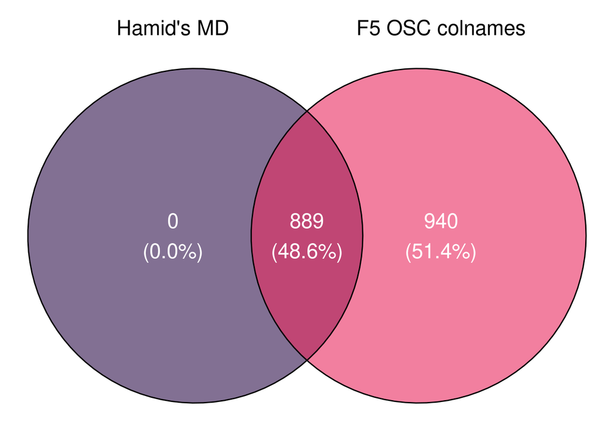

```r
x = list( "Hamid's MD" = f5_hamid$SampleID,
          "F5 OSC colnames" = names_in_osc$SampleID)

ggvenn(x[c(1,2)], fill_color = c("#2F124B", "#EA2A5F"),
                   set_name_color = "black", text_color = "white", text_size = 6,
                   stroke_size = 0.5, fill_alpha = 0.6)
```

- Noguchi et al (2017)

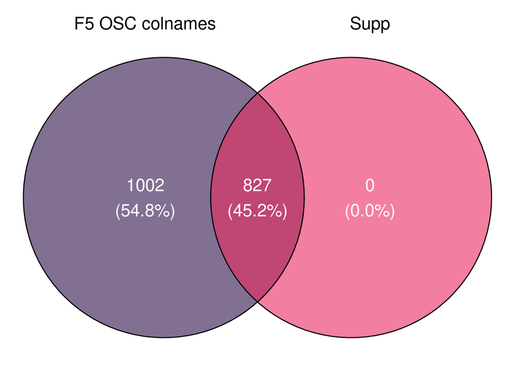

```r
x = list( "F5 OSC colnames" = names_in_osc$SampleID,
          "Supp" = merged_formatted$SampleID)
ggvenn(x[c(1,2)], fill_color = c("#2F124B", "#EA2A5F"),
       set_name_color = "black", text_color = "white", text_size = 6,
       stroke_size = 0.5, fill_alpha = 0.6)
```

- Hamid md overlap with Noguchi et al (2017)

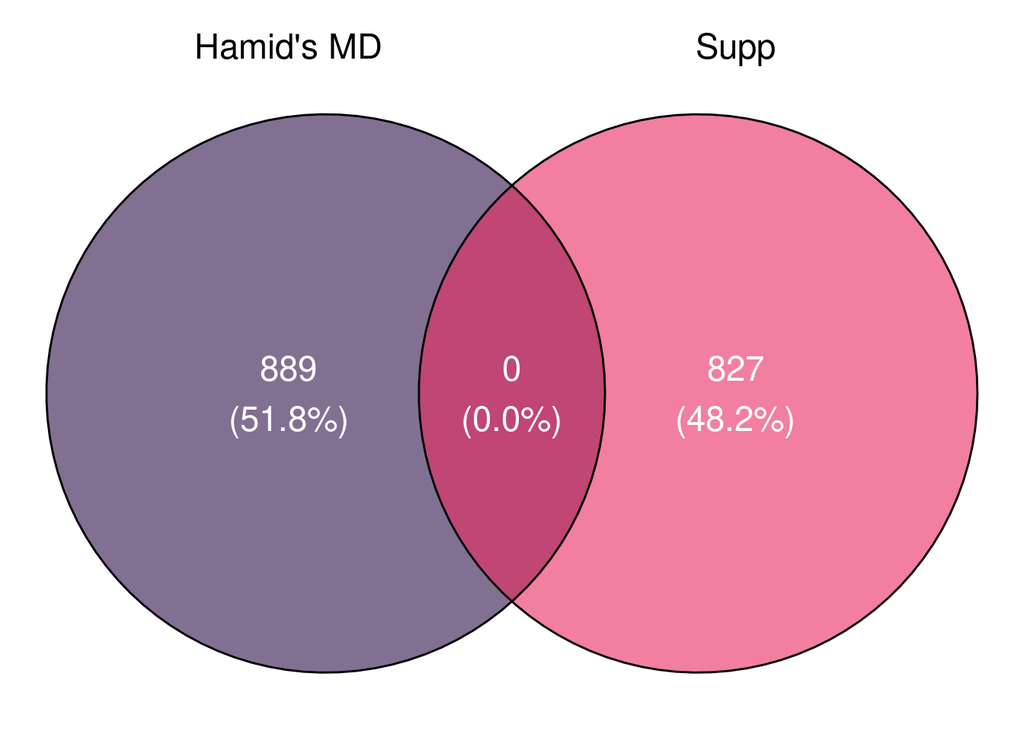

```r
x = list( "Hamid's MD" = f5_hamid$SampleID,
          "Supp" = merged_formatted$SampleID)
ggvenn(x[c(1,2)], fill_color = c("#2F124B", "#EA2A5F"),
       set_name_color = "black", text_color = "white", text_size = 6,
       stroke_size = 0.5, fill_alpha = 0.6)  ## Doesn't merge with Hamids
```